# Analysis of the Titanic Train dataset

Alice Otieno

7/11/2021

### Import data

Assigning NA to all blank cells in my data set

```r
train <- read.csv("C:/Users/tech/Desktop/train.csv",na.strings = "")
```

### load the r packages that we’ll need in our analysis

```r
library(tidyverse)
library(scales)
library(questionr)
```

### Get a glance at the data,the top 10 records and bottom 6 records

```r
head(train,10)
```

```
##    PassengerId Survived Pclass
## 1            1        0      3
## 2            2        1      1
## 3            3        1      3
## 4            4        1      1
## 5            5        0      3
## 6            6        0      3
## 7            7        0      1
## 8            8        0      3
## 9            9        1      3
## 10          10        1      2
##                                                   Name    Sex Age SibSp Parch
## 1                              Braund, Mr. Owen Harris   male  22     1     0
## 2  Cumings, Mrs. John Bradley (Florence Briggs Thayer) female  38     1     0
## 3                               Heikkinen, Miss. Laina female  26     0     0
```

[output cut: 18 more lines]

```r
tail(train)
```

```
##     PassengerId Survived Pclass                                     Name    Sex
## 886         886        0      3     Rice, Mrs. William (Margaret Norton) female
## 887         887        0      2                    Montvila, Rev. Juozas   male
## 888         888        1      1             Graham, Miss. Margaret Edith female
## 889         889        0      3 Johnston, Miss. Catherine Helen "Carrie" female
## 890         890        1      1                    Behr, Mr. Karl Howell   male
## 891         891        0      3                      Dooley, Mr. Patrick   male
##     Age SibSp Parch     Ticket   Fare Cabin Embarked
## 886  39     0     5     382652 29.125  <NA>        Q
## 887  27     0     0     211536 13.000  <NA>        S
## 888  19     0     0     112053 30.000   B42        S
## 889  NA     1     2 W./C. 6607 23.450  <NA>        S
## 890  26     0     0     111369 30.000  C148        C
## 891  32     0     0     370376  7.750  <NA>        Q
```

### See the variable names in the data set

```r
names(train)
```

```
##  [1] "PassengerId" "Survived"    "Pclass"      "Name"        "Sex"
##  [6] "Age"         "SibSp"       "Parch"       "Ticket"      "Fare"
## [11] "Cabin"       "Embarked"
```

### Structure of the data

```r
str(train)
```

```
## 'data.frame':    891 obs. of  12 variables:
##  $ PassengerId: int  1 2 3 4 5 6 7 8 9 10 ...
##  $ Survived   : int  0 1 1 1 0 0 0 0 1 1 ...
##  $ Pclass     : int  3 1 3 1 3 3 1 3 3 2 ...
##  $ Name       : chr  "Braund, Mr. Owen Harris" "Cumings, Mrs. John Bradley (Florence Briggs Thayer)" "Heikkinen, Miss. Laina" "Futrelle, Mrs. Jacques Heath (Lily May Peel)" ...
##  $ Sex        : chr  "male" "female" "female" "female" ...
##  $ Age        : num  22 38 26 35 35 NA 54 2 27 14 ...
##  $ SibSp      : int  1 1 0 1 0 0 0 3 0 1 ...
##  $ Parch      : int  0 0 0 0 0 0 0 1 2 0 ...
##  $ Ticket     : chr  "A/5 21171" "PC 17599" "STON/O2. 3101282" "113803" ...
##  $ Fare       : num  7.25 71.28 7.92 53.1 8.05 ...
##  $ Cabin      : chr  NA "C85" NA "C123" ...
##  $ Embarked   : chr  "S" "C" "S" "S" ...
```

### check for missing values

```r
freq.na(train)
```

```
##             missing  %
## Cabin           687 77
## Age             177 20
## Embarked          2  0
## PassengerId       0  0
## Survived          0  0
## Pclass            0  0
## Name              0  0
## Sex               0  0
## SibSp             0  0
## Parch             0  0
## Ticket            0  0
## Fare              0  0
```

The Embarked feature has only 2 missing values, which can easily be filled. It will be much more tricky, to deal with the ‘Age’ feature, which has 177 missing values. The ‘Cabin’ feature needs further investigation, but it looks like that we might want to drop it from the dataset, since 77 % of it are missing.

### Summary statistics of the data set

```r
summary(train)
```

```
##   PassengerId       Survived          Pclass          Name
##  Min.   :  1.0   Min.   :0.0000   Min.   :1.000   Length:891
##  1st Qu.:223.5   1st Qu.:0.0000   1st Qu.:2.000   Class :character
##  Median :446.0   Median :0.0000   Median :3.000   Mode  :character
##  Mean   :446.0   Mean   :0.3838   Mean   :2.309
##  3rd Qu.:668.5   3rd Qu.:1.0000   3rd Qu.:3.000
##  Max.   :891.0   Max.   :1.0000   Max.   :3.000
##
##      Sex                 Age            SibSp           Parch
##  Length:891         Min.   : 0.42   Min.   :0.000   Min.   :0.0000
##  Class :character   1st Qu.:20.12   1st Qu.:0.000   1st Qu.:0.0000
##  Mode  :character   Median :28.00   Median :0.000   Median :0.0000
##                     Mean   :29.70   Mean   :0.523   Mean   :0.3816
##                     3rd Qu.:38.00   3rd Qu.:1.000   3rd Qu.:0.0000
##                     Max.   :80.00   Max.   :8.000   Max.   :6.0000
##                     NA's   :177
##     Ticket               Fare           Cabin             Embarked
##  Length:891         Min.   :  0.00   Length:891         Length:891
##  Class :character   1st Qu.:  7.91   Class :character   Class :character
##  Mode  :character   Median : 14.45   Mode  :character   Mode  :character
##                     Mean   : 32.20
##                     3rd Qu.: 31.00
##                     Max.   :512.33
##
```

### Some variables in the data set are considered numeric and some as character but they are factors so we change the datatypes

```r
train$Survived <-as.factor(train$Survived)
train$Pclass <-as.factor(train$Pclass)
train$Sex<-as.factor(train$Sex)
train$Embarked<-as.factor(train$Embarked)
str(train)
```

```
## 'data.frame':    891 obs. of  12 variables:
##  $ PassengerId: int  1 2 3 4 5 6 7 8 9 10 ...
##  $ Survived   : Factor w/ 2 levels "0","1": 1 2 2 2 1 1 1 1 2 2 ...
##  $ Pclass     : Factor w/ 3 levels "1","2","3": 3 1 3 1 3 3 1 3 3 2 ...
##  $ Name       : chr  "Braund, Mr. Owen Harris" "Cumings, Mrs. John Bradley (Florence Briggs Thayer)" "Heikkinen, Miss. Laina" "Futrelle, Mrs. Jacques Heath (Lily May Peel)" ...
##  $ Sex        : Factor w/ 2 levels "female","male": 2 1 1 1 2 2 2 2 1 1 ...
##  $ Age        : num  22 38 26 35 35 NA 54 2 27 14 ...
##  $ SibSp      : int  1 1 0 1 0 0 0 3 0 1 ...
##  $ Parch      : int  0 0 0 0 0 0 0 1 2 0 ...
##  $ Ticket     : chr  "A/5 21171" "PC 17599" "STON/O2. 3101282" "113803" ...
##  $ Fare       : num  7.25 71.28 7.92 53.1 8.05 ...
##  $ Cabin      : chr  NA "C85" NA "C123" ...
##  $ Embarked   : Factor w/ 3 levels "C","Q","S": 3 1 3 3 3 2 3 3 3 1 ...
```

## Analysis and Visualization

This is the art of turning data into insight that can be easily interpreted as insight. we’ll check for survival patterns and check for factors that affected the same

### what was the survival rate?

We use a simple bar graph to demonstrate the survival rate 0 represents the passengers that did not survive, and 1 represents those that did survive.

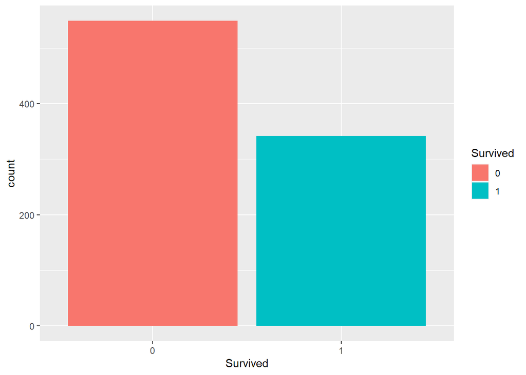

```r
ggplot(train,aes(x=Survived,fill=Survived))+geom_bar()
```

```r
prop.table(table(train$Survived))
```

```
##
##         0         1
## 0.6161616 0.3838384
```

From our bar graph we see that ~550 passengers did not survive, which is roughly 61% of the total, and ~340 (38%) survived

### Survival rate basis Gender

it is believed that in case of a rescue operation during disasters, women’s safety is prioritized.Did the same happen?

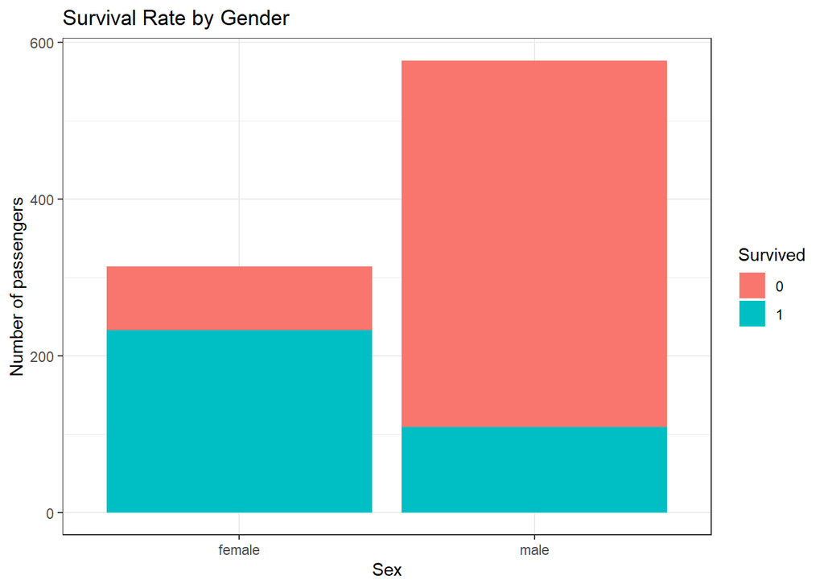

```r
ggplot(train,aes(x=Sex,fill=Survived))+
  theme_bw()+
  geom_bar()+
  labs(y="Number of passengers",
  title="Survival Rate by Gender")
```

```r
prop.table(table(train$Survived,train$Sex))
```

```
##
##         female       male
##   0 0.09090909 0.52525253
##   1 0.26150393 0.12233446
```

The survival rate amongst women was significantly higher,compare to men.

### Survival rate basis class of tickets(Pclass)

There are 3levels of the ticket class,namely 1,2 and 3.

I presume the passengers in the pclass 1 were given first priority, is it the case?

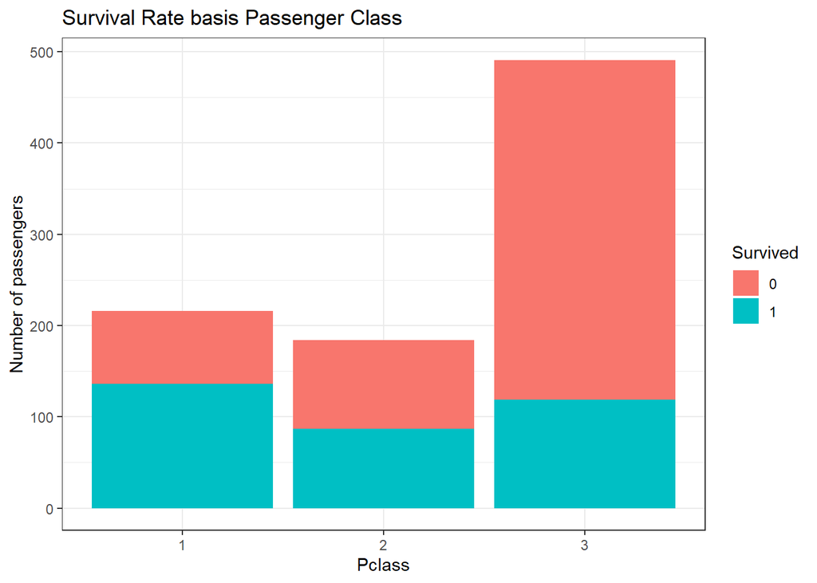

```r
ggplot(train,aes(x=Pclass,fill=Survived))+
  theme_bw()+
  geom_bar()+
  labs(y="Number of passengers",
       title="Survival Rate basis Passenger Class")
```

We notice that over 50%of passengers used the 3rd class

### Survival rate basis class of tickets(Pclass) and Gender

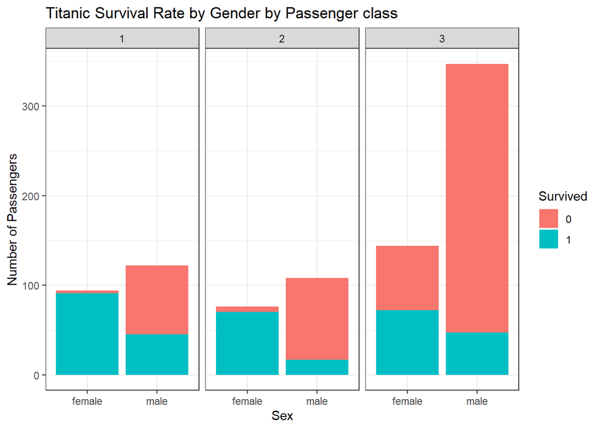

```r
ggplot(train,aes(x=Sex,fill=Survived))+
  theme_bw()+
  geom_bar()+
  labs(y="Number of Passengers",title="Titanic Survival Rate by Gender by Passenger class")+
  facet_wrap(~Pclass)
```

We can say that females were given first priority in the rescue plan. Number of female survivors was higher than male in all three passenger ticket classes.

### Survival rate basis age

We would want to know the impact of passenger’s Age on survival rate

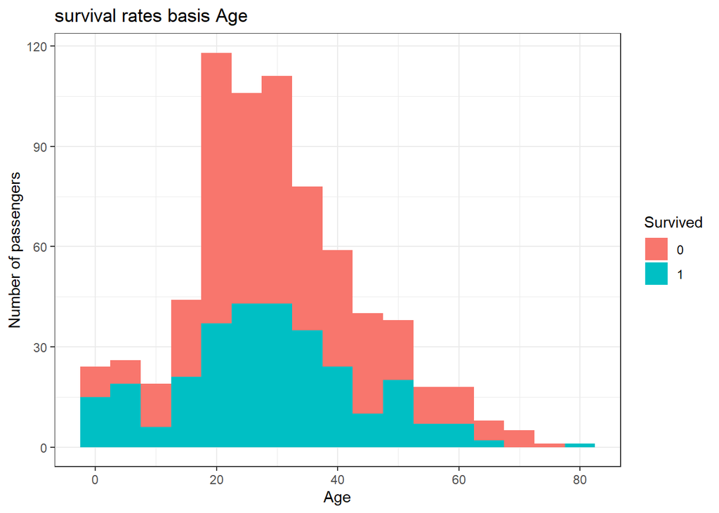

```r
ggplot(train,aes(x=Age, fill=Survived))+
    theme_bw()+
    geom_histogram(binwidth = 5)+
    labs(y="Number of passengers",x="Age", title = "survival rates basis Age")
```

### Survival rate basis Age ,Gender and Class of tickets

We also identify the survival pattern considering all the three variables

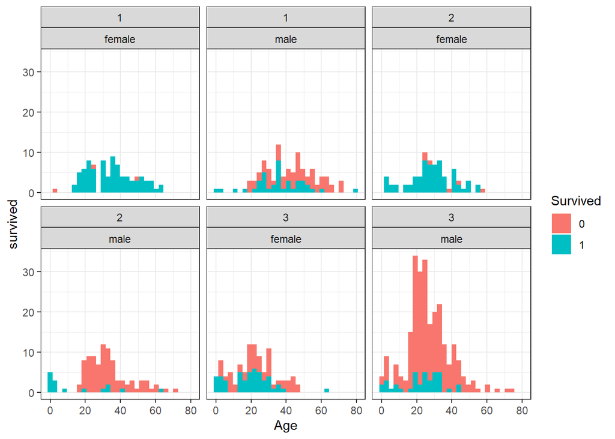

```r
ggplot(train,aes(x=Age,fill=Survived))+
  theme_bw()+
  facet_wrap(Pclass~Sex)+
  geom_histogram(bnwidth=5)+
  labs(y="survived",x="Age")
```

I It is evident that the survival rate of children,across 1st and 2nd class was the highest.

Except for 1 girl child all children travelling 1st and 2nd class survived.

The survival rates were lowest for men traveling 3rd class.

**The End**